# ME810 - Áreas Contaminadas

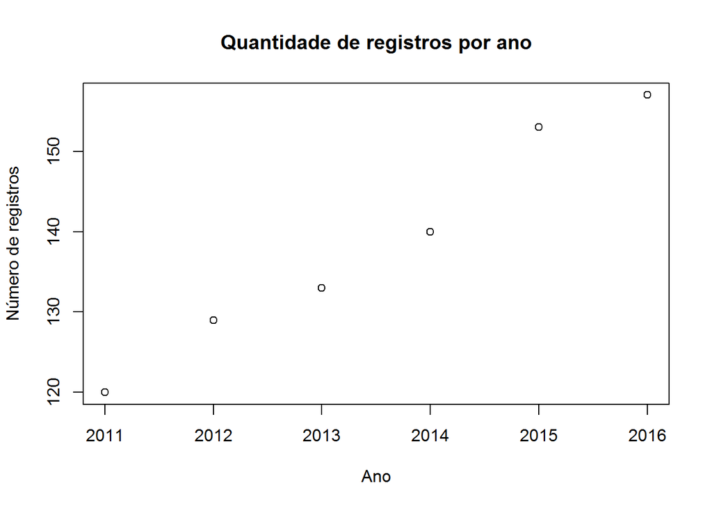

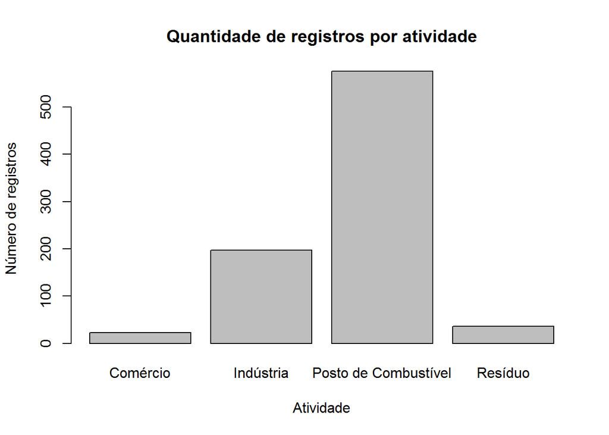

```
##  Factor w/ 98 levels "AEROPORTO","AMARAIS",..: 50 18 65 17 17 38 17 16 1 17 ...
```

```
##
##             AEROPORTO               AMARAIS               ANHUMAS
##                     6                    14                     6
##          APARECIDINHA         BARÃO GERALDO             BOA VISTA
##                     6                    19                    18
##              BOCAIUVA                BONFIM                BOSQUE
##                     6                    26                     3
##              BOTAFOGO                CAMBUI     CAMPO DOS AMARAIS
##                    12                    30                     4
##         CAMPO ELISEOS          CAMPO GRANDE               CASTELO
##                     6                     3                     6
##                 CEASA                CENTRO  CHACARA DA REPÚBLICA
##                     6                    60                     6
## CHACARA SANTA LETICIA CHACARA SÃO FRANCISCO  CHACARA SÃO MARTINHO
##                     6                     6                     6
##  CIDADE UNIVERSITARIA        COMPLEXO DELTA   DISTRITO INDUSTRIAL
##                     6                     6                    15
##          DOS PEDROSOS     FAZENDA MILITAR D  FAZENDA MONTE D'ESTE
##                     2                     4                     5
## FAZENDA SANTA CANDIDA             GUANABARA              HELVÉTIA
##                     6                    18                     6
##       Jardim Chapadão       JARDIM CHAPADÃO  JARDIM DAS BANDEIRAS
##                     1                    19                     6
##  JARDIM DAS OLIVEIRAS        JARDIM DO LAGO    JARDIM DO PLANALTO
##                     6                    13                     6
##       JARDIM DO TREVO         JARDIM EULINA     JARDIM FLAMBOYANT
##                     8                    12                     6
##     JARDIM INTERLAGOS       JARDIM ITATINGA         JARDIM LEONOR
##                     6                     6                     6
##     JARDIM MARIA ROSA       JARDIM MERCEDES         JARDIM NOÊMIA
##                     6                     6                     6
##   JARDIM NOVA AMERICA    JARDIM NOVA EUROPA       JARDIM PACAEMBU
##                     6                     6                     6
##        JARDIM PARAISO        JARDIM PROENÇA      JARDIM SAMAMBAIA
##                     5                    12                     6
##  JARDIM SANTA CANDIDA  JARDIM SANTA GENEBRA       JARDIM SÃO JOSÉ
##                     2                    12                     8
##     JARDIM SAO MARCOS     JARDIM SÃO MARCOS  JARDIM SATELITE IRIS
##                     1                     5                     6
##         JARDIM SOUSAS           JD CHAPADÃO      JD DAS OLIVEIRAS
```

[output cut: 12 more lines]

```
##                     1                     2                     3
##          SÃO BERNARDO                SOUSAS              TAQUARAL
##                     9                     8                    47
##           TRES MARIAS        VILA BOA VISTA          VILA BOURBON
##                     6                    13                     6
##         VILA BRANDINA    VILA COSTA E SILVA         VILA GEORGINA
##                     6                     6                     6
##       VILA INDUSTRIAL          VILA ITAPURA   VILA JOAQUIM INACIO
##                    31                     6                     6
##            VILA JORGE             VILA NOVA          VILA POMPÉIA
##                     5                    16                     8
##        VILA PROGRESSO    VILA PROUST E SOUZ         VILA TEIXEIRA
##                     5                     6                     9
##        VILA TOTANELLO             VIRACOPOS
##                     6                    12
```

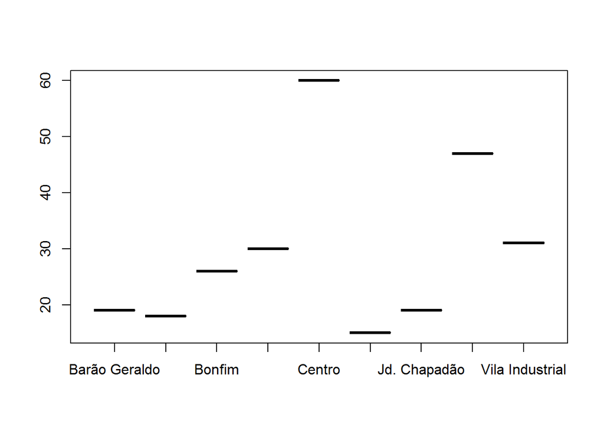

Tem como você agrupar essas categorias em apenas duas opções: contaminada e não contaminada?

```
##
##                                    Contaminada
##                                             85
##               Contaminada com risco confirmado
##                                             64
##                   Contaminada sob investigação
##                                            281
## Em processo de monitoramento para encerramento
##                                            118
## Em processo de monitoramento para reabilitação
##                                             46
##                      Em processo de remediação
##                                            130
##                    Em processo de reutilizacao
##                                              5
##                                    Reabilitada
##                                             14
##                 Reabilitada para uso declarado
##                                             71
```

1. Qual o significado da variável “reutiliza”? Você acha que ela pode ajudar a explicar o aumento de áreas contaminadas?

```r
table(dados$reutiliza)
```

```
##
##   N   S
## 670 162
```

2. Note que na variável “etapa_gere” tem problemas de digitação. Você acha que ela pode ajudar a explicar o aumento de áreas contaminadas? Qual o significado da variável? Se ela for importante, peço que corrija os erros de digitação.

```r
table(dados$etapa_gere)
```

```
##
##                                                                                                                                     investigação confirmatória
##                                                                                                                                                            140
##                                                                                       investigação confirmatória investigação detalhada e plano de intervenção
##                                                                                                                                                             73
##                                                       investigação confirmatória investigação detalhada e plano de intervenção monitoramento para encerramento
##                                                                                                                                                             44
##                                                      investigação confirmatória investigação detalhada e plano de intervenção monitoramento para encerramento|
##                                                                                                                                                              8
##                                 investigação confirmatória investigação detalhada e plano de intervenção remediação com monitoramento da eficiência e eficácia
##                                                                                                                                                             70
## investigação confirmatória investigação detalhada e plano de intervenção remediação com monitoramento da eficiência e eficácia monitoramento para encerramento
##                                                                                                                                                             21
##                                investigação confirmatória investigação detalhada e plano de intervenção remediação com monitoramento da eficiência e eficácia|
##                                                                                                                                                             12
##                                                                                      investigação confirmatória investigação detalhada e plano de intervenção|
##                                                                                                                                                             19
##                                                                                                     investigação confirmatória monitoramento para encerramento
##                                                                                                                                                             15
##                                                                                                    investigação confirmatória monitoramento para encerramento|
##                                                                                                                                                              4
##                                                                               investigação confirmatória remediação com monitoramento da eficiência e eficácia
##                                                                                                                                                             10
##                                               investigação confirmatória remediação com monitoramento da eficiência e eficácia monitoramento para encerramento
##                                                                                                                                                              1
##                                              investigação confirmatória remediação com monitoramento da eficiência e eficácia monitoramento para encerramento|
```

[output cut: 37 more lines]

3.Note que na variável “etapa_gere1” tem problemas de digitação. Você acha que ela pode ajudar a explicar o aumento de áreas contaminadas? Qual o significado da variável? Se ela for importante, peço que corrija os erros de digitação.

```r
table(dados$etapa_ge_1)
```

```
##
##                                                                                                                                    avaliação de risco/gerenciamento de risco projeto de remediação investigação confirmatória|
##                                                                                                                                                                                                                              1
##                                                                                                                                                                                avaliação preliminar investigação confirmatória
##                                                                                                                                                                                                                             14
##                                                                                                                                                         avaliação preliminar investigação confirmatória investigação detalhada
##                                                                                                                                                                                                                              5
##                                                                                                               avaliação preliminar investigação confirmatória investigação detalhada avaliação de risco/gerenciamento de risco
##                                                                                                                                                                                                                             17
##                                                       avaliação preliminar investigação confirmatória investigação detalhada avaliação de risco/gerenciamento de risco concepção da remediação monitoramento para encerramento
##                                                                                                                                                                                                                              2
##                                                                 avaliação preliminar investigação confirmatória investigação detalhada avaliação de risco/gerenciamento de risco concepção da remediação projeto de remediação
##                                                                                                                                                                                                                              2
##           avaliação preliminar investigação confirmatória investigação detalhada avaliação de risco/gerenciamento de risco concepção da remediação projeto de remediação remediação com monitoramento da eficiência e eficácia
##                                                                                                                                                                                                                              8
## avaliação preliminar investigação confirmatória investigação detalhada avaliação de risco/gerenciamento de risco concepção da remediação remediação com monitoramento da eficiência e eficácia monitoramento para encerramento
##                                                                                                                                                                                                                              2
##                                                                               avaliação preliminar investigação confirmatória investigação detalhada avaliação de risco/gerenciamento de risco monitoramento para encerramento
##                                                                                                                                                                                                                              8
##                                   avaliação preliminar investigação confirmatória investigação detalhada avaliação de risco/gerenciamento de risco projeto de remediação remediação com monitoramento da eficiência e eficácia
##                                                                                                                                                                                                                              1
##   avaliação preliminar investigação confirmatória investigação detalhada avaliação de risco/gerenciamento de risco projeto de remediação remediação com monitoramento da eficiência e eficácia monitoramento para encerramento
##                                                                                                                                                                                                                              4
##                         avaliação preliminar investigação confirmatória investigação detalhada avaliação de risco/gerenciamento de risco remediação com monitoramento da eficiência e eficácia monitoramento para encerramento
##                                                                                                                                                                                                                              3
##                                                                                                                                 avaliação preliminar investigação confirmatória investigação detalhada concepção da remediação
```

[output cut: 91 more lines]

4.Note que na variável “fonte_cont” tem problemas de digitação. Você acha que ela pode ajudar a explicar o aumento de áreas contaminadas? Qual o significado da variável? Se ela for importante, peço que corrija os erros de digitação.

```r
table(dados$fonte_cont)
```

```
##
##                                                                              armazenagem
##                                                                                      459
##                                                                             armazenagem|
##                                                                                       81
##                                                                    armazenagem|acidentes
##                                                                                        5
##                                                                   armazenagem|acidentes|
##                                                                                        1
##                                             armazenagem|descarte disposição|desconhecida
##                                                                                        4
##                                            armazenagem|descarte disposição|desconhecida|
##                                                                                        1
##                      armazenagem|descarte disposição|infiltração|tratamento de efluentes
##                                                                                        1
##                           armazenagem|descarte disposição|produção|infiltração|acidentes
##                                                                                        4
##             armazenagem|descarte disposição|produção|infiltração|tratamento de efluentes
##                                                                                        2
##                                               armazenagem|descarte disposio|desconhecida
##                                                                                        1
##                          armazenagem|descarte disposio|infiltrao|tratamento de efluentes
##                                                                                        1
##                                 armazenagem|descarte disposio|produo|infiltrao|acidentes
##                                                                                        1
##                   armazenagem|descarte disposio|produo|infiltrao|tratamento de efluentes
##                                                                                        1
##                                                                 armazenagem|desconhecida
##                                                                                       10
##                                                                armazenagem|desconhecida|
##                                                                                        2
##                                                                  armazenagem|infiltração
##                                                                                       31
##                                                                 armazenagem|infiltração|
##                                                                                        4
##                                                                    armazenagem|infiltrao
##                                                                                        5
##                                                                   armazenagem|manutenção
##                                                                                       13
##                                                                  armazenagem|manutenção|
```

[output cut: 76 more lines]

```
##                                                                                        5
##                                                        produção|tratamento de efluentes|
##                                                                                        1
##                                    produção|tratamento de efluentes|descarte disposição|
##                                                                                        1
##                                                                                   produo
##                                                                                       14
##                                                                         produo|infiltrao
##                                                                                        1
##                                                                          produo|manuteno
##                                                                                        1
##                                                           produo|tratamento de efluentes
##                                                                                        2
##                                                                  tratamento de efluentes
##                                                                                        1
```

5.Note que na variável “meios_impa” tem problemas de digitação. Você acha que ela pode ajudar a explicar o aumento de áreas contaminadas? Qual o significado da variável? Se ela for importante, peço que corrija os erros de digitação.

```r
table(dados$meios_impa)
```

```
##
##                                                                                                                        águas subterrâneas#dentro#
##                                                                                                                                               155
##                                                                                                                       águas subterrâneas#dentro#|
##                                                                                                                                                37
##                                                                                               águas subterrâneas#dentro#|águas subterrâneas#fora#
##                                                                                                                                                32
##                                                                                              águas subterrâneas#dentro#|águas subterrâneas#fora#|
##                                                                                                                                                 6
##                                                                                                                          guas subterrneas#dentro#
##                                                                                                                                                39
##                                                                                                   guas subterrneas#dentro#|guas subterrneas#fora#
##                                                                                                                                                 7
##                                                                                                                          solo superficial#dentro#
##                                                                                                                                                20
##                                                                                                                         solo superficial#dentro#|
##                                                                                                                                                 3
##                                                                                               solo superficial#dentro#|águas subterrâneas#dentro#
##                                                                                                                                                42
##                                                                                              solo superficial#dentro#|águas subterrâneas#dentro#|
##                                                                                                                                                 6
##                                                                      solo superficial#dentro#|águas subterrâneas#dentro#|águas subterrâneas#fora#
##                                                                                                                                                 1
##                                                                                                 solo superficial#dentro#|guas subterrneas#dentro#
##                                                                                                                                                 8
##                                                                          solo superficial#dentro#|guas subterrneas#dentro#|guas subterrneas#fora#
##                                                                                                                                                 1
##                                                                                                          solo superficial#dentro#|subsolo#dentro#
##                                                                                                                                                16
##                                                                                                         solo superficial#dentro#|subsolo#dentro#|
##                                                                                                                                                 1
##                                                                               solo superficial#dentro#|subsolo#dentro#|águas subterrâneas#dentro#
##                                                                                                                                                82
##                                                                              solo superficial#dentro#|subsolo#dentro#|águas subterrâneas#dentro#|
##                                                                                                                                                24
##                                                      solo superficial#dentro#|subsolo#dentro#|águas subterrâneas#dentro#|águas subterrâneas#fora#
##                                                                                                                                                26
##                                                     solo superficial#dentro#|subsolo#dentro#|águas subterrâneas#dentro#|águas subterrâneas#fora#|
##                                                                                                                                                 4
##                                                                      solo superficial#dentro#|subsolo#dentro#|águas subterrâneas#dentro#|ar#fora#
```

[output cut: 16 more lines]

```
##                                                                                                                                                 3
##                                                                                                        subsolo#dentro#|águas subterrâneas#dentro#
##                                                                                                                                               131
##                                                                                                       subsolo#dentro#|águas subterrâneas#dentro#|
##                                                                                                                                                23
##                                                                               subsolo#dentro#|águas subterrâneas#dentro#|águas subterrâneas#fora#
##                                                                                                                                                38
##                                                                              subsolo#dentro#|águas subterrâneas#dentro#|águas subterrâneas#fora#|
##                                                                                                                                                 7
##                                                                                                        subsolo#dentro#|águas superficiais#dentro#
##                                                                                                                                                 1
##                                                                                                          subsolo#dentro#|guas subterrneas#dentro#
##                                                                                                                                                23
##                                                                                   subsolo#dentro#|guas subterrneas#dentro#|guas subterrneas#fora#
##                                                                                                                                                 9
```

6. Note que na variável “contaminan” tem problemas de digitação. Você que ela pode ajudr a explicar o aumento de áreas contaminadas? Qual o significado da variável? Se ela for importante, peço que corrija os erros de digitação.

```r
table(dados$contaminan)
```

```
##
##                                                                                             combustíveis líquidos
##                                                                                                                61
##                                                                    combustíveis líquidos existência de fase livre
##                                                                                                                 6
##                                                                                      combustíveis líquidos outros
##                                                                                                                 1
##                                                                        combustíveis líquidos solventes aromáticos
##                                                                                                                 7
##                                                                       combustíveis líquidos solventes aromáticos|
##                                                                                                                 2
##                                               combustíveis líquidos solventes aromáticos|existência de fase livre
##                                                                                                                 1
##                                                                   combustíveis líquidos solventes aromáticos|PAHs
##                                                                                                                10
##                                          combustíveis líquidos solventes aromáticos|PAHs|existência de fase livre
##                                                                                                                 3
##                                                                                            combustíveis líquidos|
##                                                                                                                13
##                                                                    combustíveis líquidos|existência de fase livre
##                                                                                                                16
##                                                                   combustíveis líquidos|existência de fase livre|
##                                                                                                                 7
##                                                                                      combustíveis líquidos|metais
##                                                                                                                 2
##                                                             combustíveis líquidos|metais|existência de fase livre
##                                                                                                                 1
##                                  combustíveis líquidos|metais|solventes aromáticos|PAHs|existência de fase livre|
##                                                                                                                 1
##                               combustíveis líquidos|metais|solventes aromáticos|PAHs|existência de fase livre|TPH
##                                                                                                                 3
##                                           combustíveis líquidos|metais|solventes halogenados|solventes aromáticos
##                                                                                                                 2
##                                          combustíveis líquidos|metais|solventes halogenados|solventes aromáticos|
##                                                                                                                 2
##                                       combustíveis líquidos|metais|solventes halogenados|solventes aromáticos|TPH
##                                                                                                                 1
##                                                                                  combustíveis líquidos|metais|TPH
##                                                                                                                 4
##                                                                                     combustíveis líquidos|outros|
```

[output cut: 198 more lines]

```
##                                                                                                                 1
##                                                                 solventes halogenados|metano/outros vapores/gases
##                                                                                                                 2
##                                                                                      solventes halogenados|outros
##                                                                                                                 2
##                                                                    solventes halogenados|solventes aromáticos|TPH
##                                                                                                                 1
##                                             solventes halogenados|solventes aromticos|TPH|existncia de fase livre
##                                                                                                                 1
##                                                                                         solventes halogenados|TPH
##                                                                                                                 1
##                                                                                                               TPH
##                                                                                                                 3
##                                                                                                        TPH|outros
##                                                                                                                 4
```

7. Note que na variável “med_emerge” tem problemas de digitação. Você que ela pode ajudr a explicar o aumento de áreas contaminadas? Qual o significado da variável? Se ela for importante, peço que corrija os erros de digitação.

```r
table(dados$med_emerge)
```

```
##
##                                                                                                                                                             fechamento/interdição de poços de abastecimento
##                                                                                                                                                                                                           8
##                                                                                                                                                            fechamento/interdição de poços de abastecimento|
##                                                                                                                                                                                                           6
##                                                                                                                                                                fechamento/interdio de poos de abastecimento
##                                                                                                                                                                                                           2
##                                                                                                                                                             isolamento da área (proibição de acesso à area)
##                                                                                                                                                                                                          13
##                                                                                                                                                            isolamento da área (proibição de acesso à area)|
##                                                                                                                                                                                                           2
##                                                                                                                                     isolamento da área (proibição de acesso à area)|monitoramento ambiental
##                                                                                                                                                                                                           5
##                                                                                     isolamento da área (proibição de acesso à area)|monitoramento ambiental|fechamento/interdição de poços de abastecimento
##                                                                                                                                                                                                           2
##                                     isolamento da área (proibição de acesso à area)|monitoramento ambiental|remoção de materiais (produtos, resíduos, etc.)|fechamento/interdição de poços de abastecimento
##                                                                                                                                                                                                           1
##                                                                    isolamento da área (proibição de acesso à area)|monitoramento do índice de explosividade|monitoramento ambiental|proibição de escavações
##                                                                                                                                                                                                           4
##                                                                   isolamento da área (proibição de acesso à area)|monitoramento do índice de explosividade|monitoramento ambiental|proibição de escavações|
##                                                                                                                                                                                                           1
##  isolamento da área (proibição de acesso à area)|ventilação/exaustão de espaços confinados|monitoramento do índice de explosividade|monitoramento ambiental|remoção de materiais (produtos, resíduos, etc.)
##                                                                                                                                                                                                           4
## isolamento da área (proibição de acesso à area)|ventilação/exaustão de espaços confinados|monitoramento do índice de explosividade|monitoramento ambiental|remoção de materiais (produtos, resíduos, etc.)|
##                                                                                                                                                                                                           1
##                                                                                                                                                                 isolamento da rea (proibio de acesso  area)
```

[output cut: 63 more lines]

8. Note que na variável “med_instit” tem problemas de digitação. Você que ela pode ajudr a explicar o aumento de áreas contaminadas? Qual o significado da variável? Se ela for importante, peço que corrija os erros de digitação.

```r
table(dados$med_instit)
```

```
##
##                                                                                                      consumo alimentos#proposta#
##                                                                                                                                1
##                                                edificações#implantada#|uso água subterrânea#implantada#|uso de solo#implantada#|
##                                                                                                                                1
##                                                                          edificações#implantada#|uso água subterrânea#proposta#|
##                                                                                                                                2
##                           trabalhadores de obras#proposta#|trabalhadores de obras#comunicada#|trabalhadores de obras#implantada#
##                                                                                                                                1
##                                                                                                 uso água subterrânea#comunicada#
##                                                                                                                               78
##                                                                                                uso água subterrânea#comunicada#|
##                                                                                                                               17
##                                                                uso água subterrânea#comunicada#|uso água subterrânea#implantada#
##                                                                                                                               16
##                                                                                                 uso água subterrânea#implantada#
##                                                                                                                                4
##                                                                                                uso água subterrânea#implantada#|
##                                                                                                                                1
##                                                               uso água subterrânea#implantada#|uso água subterrânea#comunicada#|
##                                                                                                                                3
##                                                                 uso água subterrânea#implantada#|uso água subterrânea#proposta#|
##                                                                                                                                1
##                                       uso água subterrânea#implantada#|uso de solo#comunicada#|uso água subterrânea#comunicada#|
##                                                                                                                                1
##                                                                                                   uso água subterrânea#proposta#
##                                                                                                                               93
##                                                                                                  uso água subterrânea#proposta#|
##                                                                                                                               17
##                                                                       uso água subterrânea#proposta#|consumo alimentos#proposta#
##                                                                                                                                1
##                                                                           uso água subterrânea#proposta#|edificações#implantada#
##                                                                                                                                3
##                                                                  uso água subterrânea#proposta#|trabalhadores de obras#proposta#
##                                                                                                                                1
##                                                                 uso água subterrânea#proposta#|trabalhadores de obras#proposta#|
##                                                                                                                                1
##                                                                  uso água subterrânea#proposta#|uso água subterrânea#comunicada#
##                                                                                                                               52
##                                                                 uso água subterrânea#proposta#|uso água subterrânea#comunicada#|
```

[output cut: 50 more lines]

```
##                                                                                                                                1
##                                                                                                   uso gua subterrnea#comunicada#
##                                                                                                                               13
##                                                                    uso gua subterrnea#comunicada#|uso gua subterrnea#implantada#
##                                                                                                                                2
##                                                                                                   uso gua subterrnea#implantada#
##                                                                                                                                1
##                                                                                                     uso gua subterrnea#proposta#
##                                                                                                                               28
##                                                                  uso gua subterrnea#proposta#|trabalhadores de obras#implantada#
##                                                                                                                                1
##                                                                      uso gua subterrnea#proposta#|uso gua subterrnea#comunicada#
##                                                                                                                               14
##        uso gua subterrnea#proposta#|uso gua subterrnea#comunicada#|uso gua superficial#proposta#|uso gua superficial#comunicada#
##                                                                                                                                1
```

9. Note que na variável “med_remedi” tem problemas de digitação. Você que ela pode ajudr a explicar o aumento de áreas contaminadas? Qual o significado da variável? Se ela for importante, peço que corrija os erros de digitação.

```r
table(dados$med_remedi)
```

```
##
##                                                                                                                                                                      atenuação natural monitorada
##                                                                                                                                                                                                17
##                                                                                                                                                                     atenuação natural monitorada|
##                                                                                                                                                                                                 3
##                                                                                                                                                                        atenuao natural monitorada
##                                                                                                                                                                                                 3
##                                                                                                                                                                                    biorremediação
##                                                                                                                                                                                                 4
##                                                                                                                                                                                   biorremediação|
##                                                                                                                                                                                                 1
##                                                                                                                                                                                      biorremediao
##                                                                                                                                                                                                 1
##                                                                                                                                                                          bombeamento e tratamento
##                                                                                                                                                                                                49
##                                                                                                                                                                         bombeamento e tratamento|
##                                                                                                                                                                                                 7
##                                                                                                                                                              bombeamento e tratamento|biosparging
##                                                                                                                                                                                                 1
##                                                                                               bombeamento e tratamento|biosparging|oxidação/redução química|remoção de solo/Resíduobiorremediação
##                                                                                                                                                                                                 3
##                                                                                              bombeamento e tratamento|biosparging|oxidação/redução química|remoção de solo/Resíduobiorremediação|
##                                                                                                                                                                                                 1
##                                                                                                                        bombeamento e tratamento|biosparging|remoção de solo/Resíduobiorremediação
##                                                                                                                                                                                                 1
##                                                                                                                                        bombeamento e tratamento|extração de vapores do solo (SVE)
```

[output cut: 105 more lines]